# Assignment 3, Task 1

Alessandra Puig-Santana

2023-03-01

# Introduction

In this task, I am exploring a data set through principal components analysis (PCA) and visualizing it through a biplot and a screeplot. I am using data compiled and provided by @zander_venter on Kaggle, described as: “This data is all acquired through Google Earth Engine (https://earthengine.google.com/) where publicly available remote sensing datasets have been uploaded… Most of the data is derived by calculating the mean for each country at a reduction scale of about 10km” . It includes information on seasonality, temperature, rainfall, accessibility to cities, tree cover and more for each country. A subset was created to look at the relationships between accessibility to cities, tree canopy cover, mean annual rain, mean annual temperature, temperature seasonality, wind, and cloudiness for each county.

To visualize the relationship between variables, a biplot is generated in order to determine how the variance is explained as well as how each variable contributes to the variance plotted. The biplot converts a multidimensional dataset into a 2-dimensional visualization. Additionally, a screeplot is generated to understand to see the variance explained by each principal component.

```r
knitr::opts_chunk$set(echo = TRUE, message = FALSE, warning = FALSE)

# Set up chunk
library(tidyverse)
library(here)
library(ggfortify)
library(janitor)
```

```r
# Read in data
world_env_vars_clean <- read_csv(here("data", "world_env_vars.csv")) %>%
  clean_names() %>%
  drop_na() # drop all NA values
```

## Data wrangling

```r
# Data wrangling

world_clean <- world_env_vars_clean %>%
      select(country, accessibility_to_cities, tree_canopy_cover, rain_mean_annual, temp_mean_annual, temp_seasonality, wind, cloudiness) %>%
    rename("Accessibility to cities"= "accessibility_to_cities",
         "Tree canopy cover" = "tree_canopy_cover",
         "Mean annual rain" = "rain_mean_annual",
         "Mean annual temp" = "temp_mean_annual",
         "Temp seasonality" = "temp_seasonality",
         "Wind" = "wind",
         "Cloudiness" = "cloudiness") %>%
  select(where(is.numeric))

world_pca <- world_clean %>%
  scale() %>%
  prcomp()

# loadings check
## world_pca$rotation
```

# Biplot

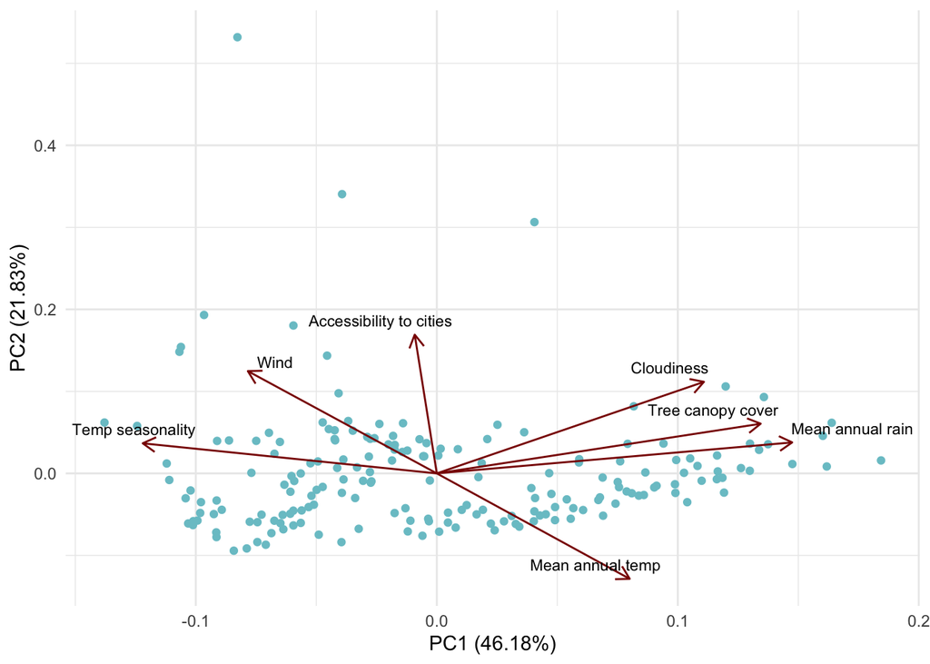

```r
#biplot

autoplot(world_pca,
        data = world_clean,
        loadings.label = TRUE,
        loadings.colour = "darkred",
        loadings.label.colour = "black",
        colour = 'cadetblue3',
        loadings.label.vjust = 0.9,
        loadings.label.size = 3,
        loadings.label.repel = T) +
  theme_minimal()
```

**Figure 1: Biplot.** The red vectors represent the variables and the length of these vectors show to what extend the variance of PC1 and PC2 is explained by the variable. The light blue points are the projection of the data onto the two dimensional space.